# Influences on Mr.Cat Julian’s mood

## Does new data mirror a pattern in mean mood for Julian, since project 2?

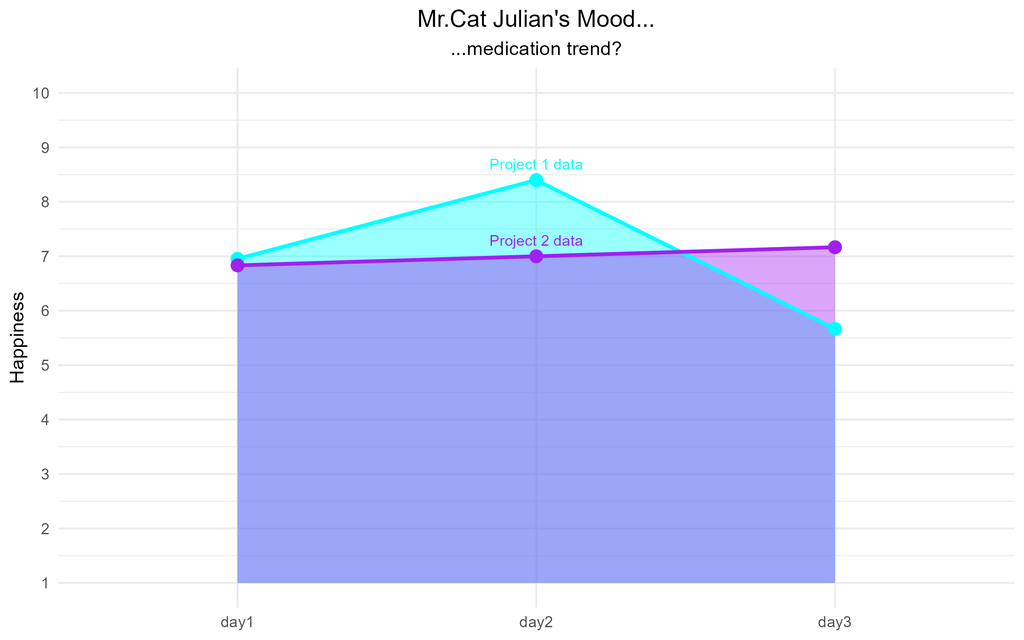

Julian’s mood still does not show an appreciable trend across time through days in the medication cycle, nor appreciably matches the trend pattern from earlier Project 2.

## Does Julian’s moodiness change according to the day of his med cycle?

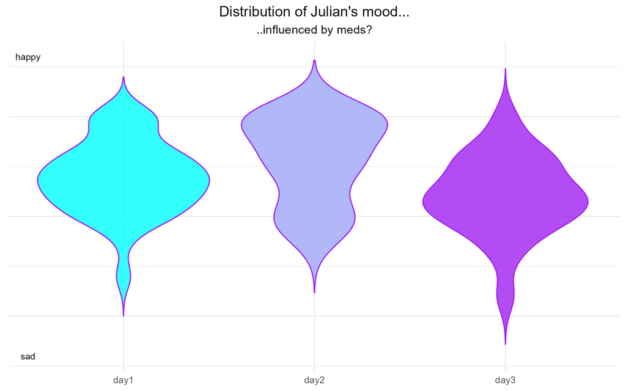

Julian’s mood distributions appear relatively comparable across days in the medication cyle

Julian’s mood distributions appear relatively comparable across days in the medication cyle, suggesting time since medication does not noticeably impact how ‘moody’ Julian is. All shapes show a major mood level for each day, with some variation either side of the key mood he is feeling for that day. Hormones have time cycles and can have complex interactions and are often implicated in mood swings, but here there is no obvious effect.

## Is Julian’s change in mood instead associated with the part of the day?

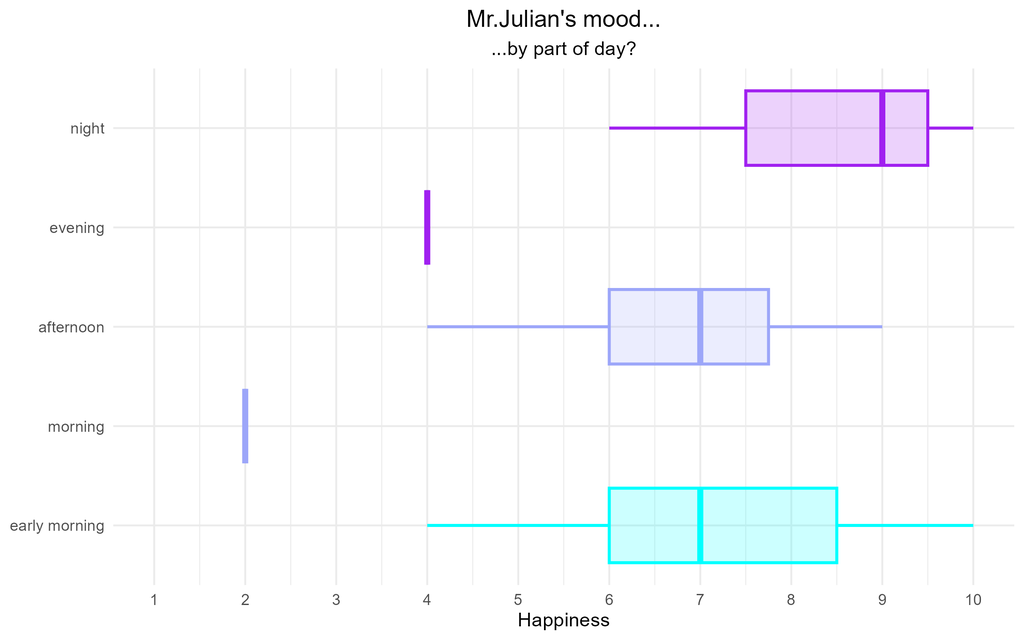

Boxplots of Julians mood by part of the day

Because of my university commitments, and Julian’s personal schedule to explore his territory, I have less data for morning and evening. The data would suggest Julian is appreciably happier at night, from the hours of 7 to 12pm. Maybe this is when he is most awake and most active and potentially feels secure with the cover of darkness and the absence of strange humans. This is also when I feed him his wetfood because I am available to do so, and this may also explain his better mood at night. This result matches my gut feeling that Julian is happier at night.

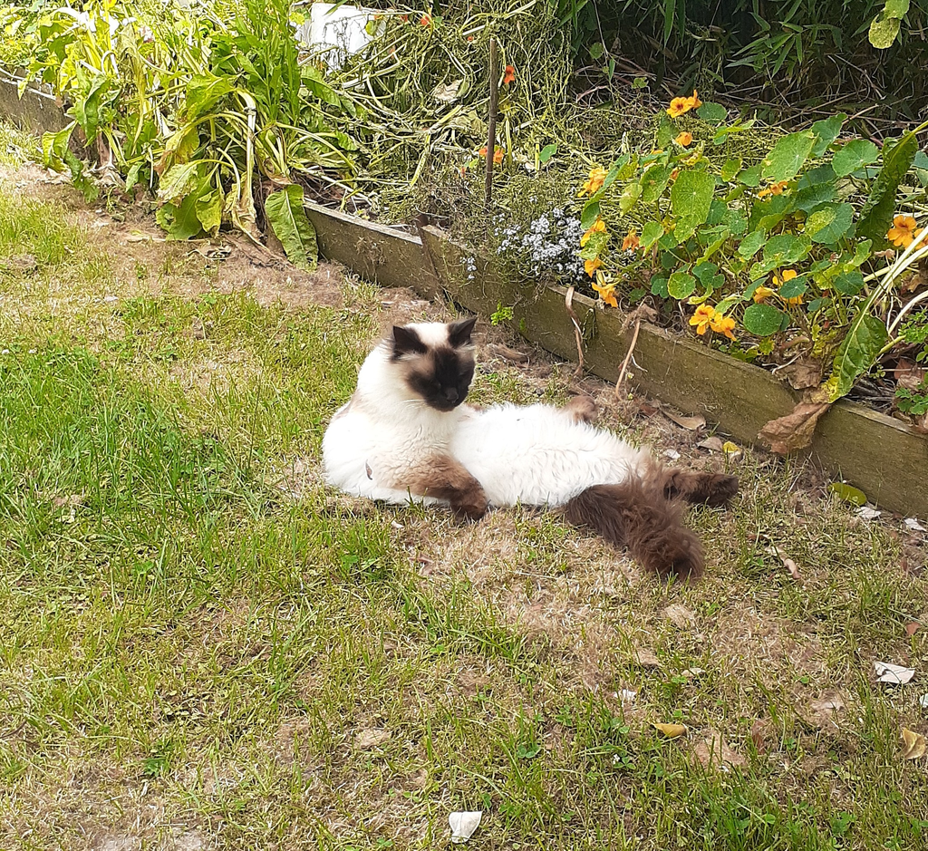

Photo of Julian in the backyard